# SOK-2008 - Seminaroppgaver til Tema 1 – introduksjon til arbeidsmarkedsøkonomi

## Oppgaver

Helle har nettopp blitt voksen og flyttet hjemifra. Helle er glad i å ha tid til å være med venner, trimme, og bare ha fri. Samtidig må hun ha penger til mat og for å kunne drive med tingene hun liker. Helle må ta et valg om hvor mye hun skal jobbe. Hun har totalt $T$ timer tilgjengelig. Disse timene kan hun bruke til å ha fri ($l$), og til å jobbe ($h$).

La oss anta at vi kan skrive Helle sin nytte som en funksjon av sammensatt konsum ($c$) og fritid ($l$): $U(c,l)$. Vi antar videre at konsum og fritid er normale goder og at grensenytten er avtakende. Nyttefunksjonen her nede tilfredsstiller disse antagelsene.

$$U(c, l) = c^\alpha \cdot l^\beta \quad 0 < \alpha, \beta < 1, \; \alpha + \beta \leq 1$$

I denne oppgaven tenker vi oss at Helle kan velge sin arbeidstid fritt, men hun kan ikke påvirke sin timelønn (hun er pristaker).

Helle har en arbeidsfri realinntekt (f.eks bidrag fra foreldre) lik $m =\frac{M}{p}$, som hun får uansett om hun jobber eller ikke. Dersom Helle velger å jobbe får hun en realtimelønn, $w = \ \frac{W}{p}$ pr. time. Vi antar at Helle ikke sparer, og ikke kan låne penger.

## a) Sett opp en ligning som beskriver Helle sin budsjettbetingelse.

$$m + w \cdot h = c$$

### Budsjettbetingelsen: Samfunnsøkonomisk Intuisjon

Budsjettbetingelsen $m + wh = c$ (du kan også skrive $m+w(T-l)$) representerer hvordan en arbeidstaker (i dette tilfellet, Helle) balanserer sin inntekt og konsum basert på tiden hun bruker på arbeid og fritid. La oss bryte ned de økonomiske komponentene i ligningen:

- $m$ er Helles arbeidsfrie realinntekt, som kan være penger hun mottar fra andre kilder, som f.eks. bidrag fra foreldre, stønader eller andre overføringer som hun får uansett om hun jobber eller ikke.
- $w$ er timelønn, eller reallønn per time. Dette representerer hvor mye hun tjener for hver time hun jobber.
- $h$ er antall timer Helle velger å jobbe. Jo flere timer hun jobber, desto høyere blir hennes inntekt fra arbeid.
- $c$ er konsum, som representerer utgiftene til varer og tjenester.

### Intuisjonen

Budsjettbetingelsen sier at Helles totale inntekt, som består av arbeidsfri inntekt $m$ pluss inntekt fra arbeid $wh$, må være lik hennes totale konsum $c$. Hun må altså bruke hele sin tilgjengelige inntekt til konsum, og kan ikke bruke mer enn hun har. Budsjettbetingelsen viser at Helle står overfor en avveining mellom fritid og konsum. Hver time hun velger å bruke på fritid, er en time hun ikke kan jobbe, og dermed mister hun inntekt tilsvarende $w$. Denne avveiningen representerer den marginale kostnaden ved fritid. Hvis hun ønsker mer fritid $l$, må hun akseptere lavere inntekt, og dermed lavere konsum. Arbeidsfri inntekt $m$ gir Helle muligheten til å konsumere selv om hun ikke jobber i det hele tatt. Jo høyere $m$, desto mindre arbeidstid $h$ trenger hun for å oppnå et gitt nivå av konsum. Dette påvirker hennes reservasjonslønn, som er den laveste lønnen hun er villig til å akseptere for å begynne å jobbe. En høyere arbeidsfri inntekt gjør at hun kan velge å jobbe mindre, eller til og med ikke i det hele tatt, hvis $m$ er høy nok.

## b) Tegn en graf som illustrerer Helle sine preferanser (indifferenskurver) og hennes budsjettbetingelse

## Grafisk analyse

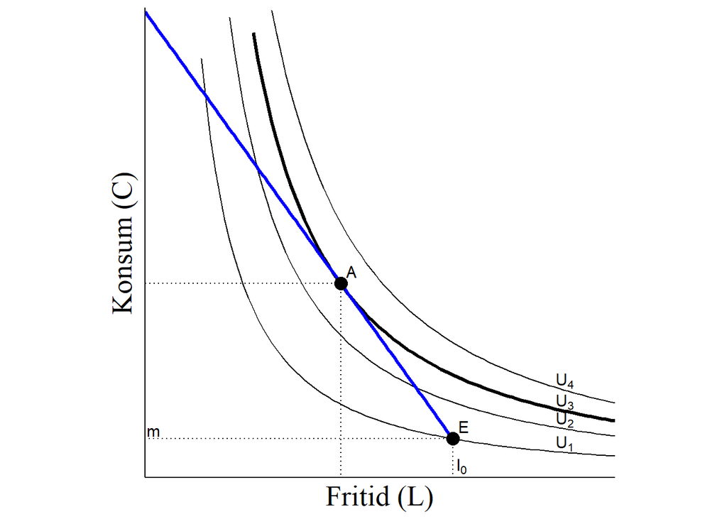

```r
# Clear the workspace
rm(list = ls())
library(extrafont)

suppressPackageStartupMessages(library(tidyverse))

    # Opprette en sekvens og lagre den i l_1
    l_1 <- seq(0, 168)  # l_1 representerer fritid, går fra 70 til 200

    # Konverterer sekvensen til en data.frame
    df <- data.frame(l_1)  # Dette gjør det enklere å håndtere i ggplot

    # Forbereder en ggplot-graf med definerte estetiske verdier og navn på aksene
    # Definer plottet med akser
    axes_1 <- ggplot(df, aes(l_1)) +
      labs(
        x = "Fritid (L)",
        y = "Konsum (C)") +
      coord_fixed(ratio = 168/12100) +  # sørg for at skalaen for x og y er den samme
      theme(axis.title = element_text(size = 20),
            panel.background = element_blank(),  # hvit bakgrunn
            axis.line = element_line(colour = "black"),  # tegn akselinjer
           # axis.ticks = element_line(),  # vis tick marks
           axis.ticks = element_blank(),  # ta bort tick marks
           axis.text.x = element_blank(),  # vis x-akseetiketter
            axis.text.y = element_blank(),  # vis y-akseetiketter
            text = element_text(family = "Times New Roman")) +  # Sett standard font til Times New Roman
      scale_x_continuous(limits = c(0, 168), expand = c(0, 0)) +  # begrens akser og sett tick marks
      scale_y_continuous(limits = c(0, 12100), expand = c(0, 0))  # begrens akser og sett tick marks

    # Definer Cobb-Douglas nyttefunksjoner
    alpha <- 0.58333333333
    U_1 <- 276.35
    U_2 <- 364
    U_3 <- 414.01  # Justerer nyttenivåer slik at de passer inn i figuren
    U_4 <- 464


    # Funksjoner for indifferenskurver
    C_1 <- function(l_1) (U_1 / (l_1^alpha))^(1 / (1 - alpha))
    C_2 <- function(l_1) (U_2 / (l_1^alpha))^(1 / (1 - alpha))
    C_3 <- function(l_1) (U_3 / (l_1^alpha))^(1 / (1 - alpha))
    C_4 <- function(l_1) (U_4 / (l_1^alpha))^(1 / (1 - alpha))

    # Definer budsjetbetingelsen
    budget_constraint <- function(l_1) {
      12000 - 100 * l_1
    }

    # Definer ligningen for reservasjonslønna

    reservation_wage <- function(l_1) {
      c=2400.3 - 12.73*l_1
    }

    # Legg til inndifferenskurvene i figuren
    figure_1 <- axes_1 +
      stat_function(fun = C_1, aes(colour = NULL), colour = "black") +
      stat_function(fun = C_2, aes(colour = NULL), colour = "black") +
      stat_function(fun = C_3, aes(colour = NULL), colour = "black", size = 1.2) +  # Tykkere linje for U_3
      stat_function(fun = C_4, aes(colour = NULL), colour = "black") +
      annotate("text", x = 150, y = C_1(150), label = "U[1]",size = 4, parse = TRUE, vjust = -0.1) +
      annotate("text", x = 150, y = C_2(150), label = "U[2]",size = 4, parse = TRUE, vjust = -0.1) +
      annotate("text", x = 150, y = C_3(150), label = "U[3]",size = 4, parse = TRUE, vjust = -0.1) +
      annotate("text", x = 150, y = C_4(150), label = "U[4]",size = 4, parse = TRUE, vjust = -0.1) +
      stat_function(fun = budget_constraint, aes(colour = NULL), colour = "blue", xlim = c(0, 110), size = 1.2) +  # Tykkere linje for budsjett
      geom_segment(aes(x = 70, y = 5000, xend = 70, yend = 0), linetype = "dotted") +
      geom_segment(aes(x = 70, y = 5000, xend = 0, yend = 5000), linetype = "dotted") +
      geom_segment(aes(x = 110, y = 1000, xend = 0, yend = 1000), linetype = "dotted") + # horisontal linje fra (70, 5000) til (70, 0)
      geom_point(aes(x = 70, y = 5000), colour = "black", size = 4) +  # Svart prikk på (70, 5000)
      annotate("text", x = 72, y = 5000, label = "A", hjust = 0, size = 4, vjust = -0.5) +  # Merk prikk "P"
      geom_segment(aes(x = 110, y = 1000, xend = 110, yend = 0), linetype = "dotted") +  #Vertikal linje fra (70, 5000) til (70, 11000)
      geom_point(aes(x = 110, y = 1000), colour = "black", size = 4) +  # Svart prikk på (110, 1000)
      annotate("text", x = 112, y = 1000, label = "E", hjust = 0, size = 4, vjust = -0.5)+ # Merk prikk "E"
      annotate("text", x = 115, y = 300, label = "l[0]", hjust = 1, size = 4, parse = TRUE) +
      annotate("text", x = 3, y = 1300, label = "m", vjust = 1, size = 4, parse = TRUE)


    # Skriv ut figuren
    print(figure_1)
```

## c) Identifiser Helle sin reservasjonslønn grafisk. Gi økonomisk intuisjon.

## Grafisk analyse

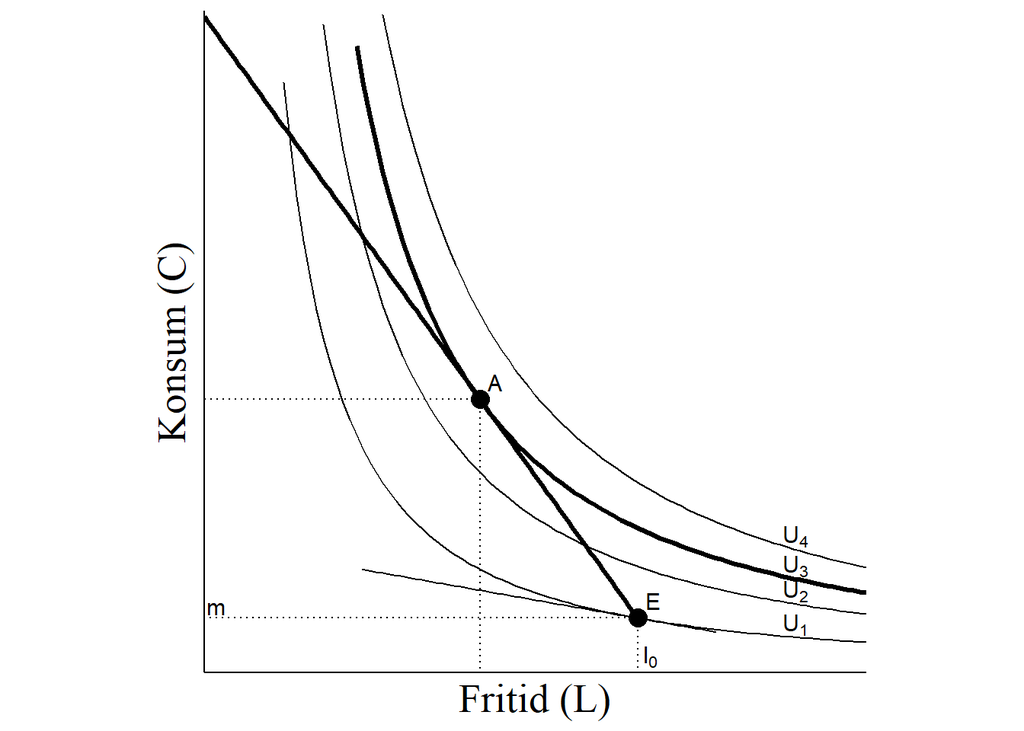

```r
# Clear the workspace
rm(list = ls())
library(extrafont)

suppressPackageStartupMessages(library(tidyverse))

    # Opprette en sekvens og lagre den i l_1
    l_1 <- seq(0, 168)  # l_1 representerer fritid, går fra 70 til 200

    # Konverterer sekvensen til en data.frame
    df <- data.frame(l_1)  # Dette gjør det enklere å håndtere i ggplot

    # Forbereder en ggplot-graf med definerte estetiske verdier og navn på aksene
    # Definer plottet med akser
    axes_1 <- ggplot(df, aes(l_1)) +
      labs(
        x = "Fritid (L)",
        y = "Konsum (C)") +
      coord_fixed(ratio = 168/12100) +  # sørg for at skalaen for x og y er den samme
      theme(axis.title = element_text(size = 20),
            panel.background = element_blank(),  # hvit bakgrunn
            axis.line = element_line(colour = "black"),  # tegn akselinjer
           # axis.ticks = element_line(),  # vis tick marks
           axis.ticks = element_blank(),  # ta bort tick marks
           axis.text.x = element_blank(),  # vis x-akseetiketter
            axis.text.y = element_blank(),  # vis y-akseetiketter
            text = element_text(family = "Times New Roman")) +  # Sett standard font til Times New Roman
      scale_x_continuous(limits = c(0, 168), expand = c(0, 0)) +  # begrens akser og sett tick marks
      scale_y_continuous(limits = c(0, 12100), expand = c(0, 0))  # begrens akser og sett tick marks

    # Definer Cobb-Douglas nyttefunksjoner
    alpha <- 0.58333333333
    U_1 <- 276.35
    U_2 <- 364
    U_3 <- 414.01  # Justerer nyttenivåer slik at de passer inn i figuren
    U_4 <- 464


    # Funksjoner for indifferenskurver
    C_1 <- function(l_1) (U_1 / (l_1^alpha))^(1 / (1 - alpha))
    C_2 <- function(l_1) (U_2 / (l_1^alpha))^(1 / (1 - alpha))
    C_3 <- function(l_1) (U_3 / (l_1^alpha))^(1 / (1 - alpha))
    C_4 <- function(l_1) (U_4 / (l_1^alpha))^(1 / (1 - alpha))

    # Definer budsjetbetingelsen
    budget_constraint <- function(l_1) {
      12000 - 100 * l_1
    }

    # Definer ligningen for reservasjonslønna

    reservation_wage <- function(l_1) {
      2400.3 - 12.73 * l_1
    }

    # Legg til inndifferenskurvene i figuren
    figure_2 <- axes_1 +
      stat_function(fun = C_1, aes(colour = NULL), colour = "black") +
      stat_function(fun = C_2, aes(colour = NULL), colour = "black") +
      stat_function(fun = C_3, aes(colour = NULL), colour = "black", size = 1.2) +  # Tykkere linje for U_3
      stat_function(fun = C_4, aes(colour = NULL), colour = "black") +
      annotate("text", x = 150, y = C_1(150), label = "U[1]",size = 4, parse = TRUE, vjust = -0.1) +
      annotate("text", x = 150, y = C_2(150), label = "U[2]",size = 4, parse = TRUE, vjust = -0.1) +
      annotate("text", x = 150, y = C_3(150), label = "U[3]",size = 4, parse = TRUE, vjust = -0.1) +
      annotate("text", x = 150, y = C_4(150), label = "U[4]",size = 4, parse = TRUE, vjust = -0.1) +
      stat_function(fun = reservation_wage, aes(colour = NULL), colour = "black", xlim = c(40, 130)) +
      stat_function(fun = budget_constraint, aes(colour = NULL), colour = "black", xlim = c(0, 110), size = 1.2) +  # Tykkere linje for budsjett
      geom_segment(aes(x = 70, y = 5000, xend = 70, yend = 0), linetype = "dotted") +
      geom_segment(aes(x = 70, y = 5000, xend = 0, yend = 5000), linetype = "dotted") +
      geom_segment(aes(x = 110, y = 1000, xend = 0, yend = 1000), linetype = "dotted") + # horisontal linje fra (70, 5000) til (70, 0)
      geom_point(aes(x = 70, y = 5000), colour = "black", size = 4) +  # Svart prikk på (70, 5000)
      annotate("text", x = 72, y = 5000, label = "A", hjust = 0, size = 4, vjust = -0.5) +  # Merk prikk "P"
      geom_segment(aes(x = 110, y = 1000, xend = 110, yend = 0), linetype = "dotted") +  #Vertikal linje fra (70, 5000) til (70, 11000)
      geom_point(aes(x = 110, y = 1000), colour = "black", size = 4) +  # Svart prikk på (110, 1000)
      annotate("text", x = 112, y = 1000, label = "E", hjust = 0, size = 4, vjust = -0.5)+ # Merk prikk "E"
      annotate("text", x = 115, y = 300, label = "l[0]", hjust = 1, size = 4, parse = TRUE) +
      annotate("text", x = 3, y = 1300, label = "m", vjust = 1, size = 4, parse = TRUE)

          # Skriv ut figuren
    print(figure_2)
```

## Intuisjon

Reservasjonslønn refererer til den laveste lønnen en arbeidstaker er villig til å akseptere for å gå inn i arbeid. Med andre ord er reservasjonslønn den lønnen som akkurat gjør at en person er indifferent mellom å jobbe og å ikke jobbe.

Reservasjonslønn reflekterer alternativkostnaden ved å jobbe. Hvis en person har andre sterke preferanser for fritid, som f.eks. å studere, ta vare på familie, eller bare nyte fritid, vil reservasjonslønnen være høyere. Jo høyere verdi den enkelte setter på alternative aktiviteter, desto høyere vil deres reservasjonslønn være. En person som verdsetter fritid høyt, vil ha en høyere reservasjonslønn fordi de trenger mer kompensasjon for å ofre fritid for arbeid.

Reservasjonslønn er altså et resultat av en rekke faktorer som påvirker individets beslutning om å akseptere en jobbtilbud, og det reflekterer både personlige preferanser og markedsforhold.

## d) Identifiser Helle sitt optimale valg av konsum og fritid, gitt at timelønna er høyere enn reservasjonslønna til Helle. Gi økonomisk intuisjon til hvorfor dette valget maksimerer nytten til Helle.

## Grafisk analyse

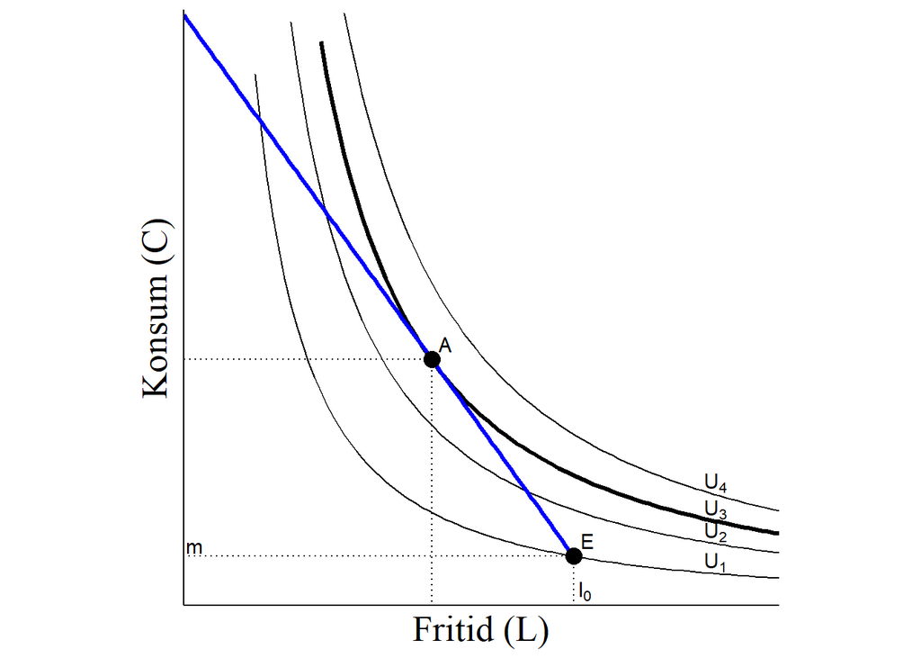

```r
# Clear the workspace
rm(list = ls())
library(extrafont)

suppressPackageStartupMessages(library(tidyverse))

    # Opprette en sekvens og lagre den i l_1
    l_1 <- seq(0, 168)  # l_1 representerer fritid, går fra 70 til 200

    # Konverterer sekvensen til en data.frame
    df <- data.frame(l_1)  # Dette gjør det enklere å håndtere i ggplot

    # Forbereder en ggplot-graf med definerte estetiske verdier og navn på aksene
    # Definer plottet med akser
    axes_1 <- ggplot(df, aes(l_1)) +
      labs(
        x = "Fritid (L)",
        y = "Konsum (C)") +
      coord_fixed(ratio = 168/12100) +  # sørg for at skalaen for x og y er den samme
      theme(axis.title = element_text(size = 20),
            panel.background = element_blank(),  # hvit bakgrunn
            axis.line = element_line(colour = "black"),  # tegn akselinjer
           # axis.ticks = element_line(),  # vis tick marks
           axis.ticks = element_blank(),  # ta bort tick marks
           axis.text.x = element_blank(),  # vis x-akseetiketter
            axis.text.y = element_blank(),  # vis y-akseetiketter
            text = element_text(family = "Times New Roman")) +  # Sett standard font til Times New Roman
      scale_x_continuous(limits = c(0, 168), expand = c(0, 0)) +  # begrens akser og sett tick marks
      scale_y_continuous(limits = c(0, 12100), expand = c(0, 0))  # begrens akser og sett tick marks

    # Definer Cobb-Douglas nyttefunksjoner
    alpha <- 0.58333333333
    U_1 <- 276.35
    U_2 <- 364
    U_3 <- 414.01  # Justerer nyttenivåer slik at de passer inn i figuren
    U_4 <- 464


    # Funksjoner for indifferenskurver
    C_1 <- function(l_1) (U_1 / (l_1^alpha))^(1 / (1 - alpha))
    C_2 <- function(l_1) (U_2 / (l_1^alpha))^(1 / (1 - alpha))
    C_3 <- function(l_1) (U_3 / (l_1^alpha))^(1 / (1 - alpha))
    C_4 <- function(l_1) (U_4 / (l_1^alpha))^(1 / (1 - alpha))

    # Definer budsjetbetingelsen
    budget_constraint <- function(l_1) {
      12000 - 100 * l_1
    }

    # Definer ligningen for reservasjonslønna

    reservation_wage <- function(l_1) {
      c=2400.3 - 12.73*l_1
    }

    # Legg til inndifferenskurvene i figuren
    figure_1 <- axes_1 +
      stat_function(fun = C_1, aes(colour = NULL), colour = "black") +
      stat_function(fun = C_2, aes(colour = NULL), colour = "black") +
      stat_function(fun = C_3, aes(colour = NULL), colour = "black", size = 1.2) +  # Tykkere linje for U_3
      stat_function(fun = C_4, aes(colour = NULL), colour = "black") +
      annotate("text", x = 150, y = C_1(150), label = "U[1]",size = 4, parse = TRUE, vjust = -0.1) +
      annotate("text", x = 150, y = C_2(150), label = "U[2]",size = 4, parse = TRUE, vjust = -0.1) +
      annotate("text", x = 150, y = C_3(150), label = "U[3]",size = 4, parse = TRUE, vjust = -0.1) +
      annotate("text", x = 150, y = C_4(150), label = "U[4]",size = 4, parse = TRUE, vjust = -0.1) +
      stat_function(fun = budget_constraint, aes(colour = NULL), colour = "blue", xlim = c(0, 110), size = 1.2) +  # Tykkere linje for budsjett
      geom_segment(aes(x = 70, y = 5000, xend = 70, yend = 0), linetype = "dotted") +
      geom_segment(aes(x = 70, y = 5000, xend = 0, yend = 5000), linetype = "dotted") +
      geom_segment(aes(x = 110, y = 1000, xend = 0, yend = 1000), linetype = "dotted") + # horisontal linje fra (70, 5000) til (70, 0)
      geom_point(aes(x = 70, y = 5000), colour = "black", size = 4) +  # Svart prikk på (70, 5000)
      annotate("text", x = 72, y = 5000, label = "A", hjust = 0, size = 4, vjust = -0.5) +  # Merk prikk "P"
      geom_segment(aes(x = 110, y = 1000, xend = 110, yend = 0), linetype = "dotted") +  #Vertikal linje fra (70, 5000) til (70, 11000)
      geom_point(aes(x = 110, y = 1000), colour = "black", size = 4) +  # Svart prikk på (110, 1000)
      annotate("text", x = 112, y = 1000, label = "E", hjust = 0, size = 4, vjust = -0.5)+ # Merk prikk "E"
      annotate("text", x = 115, y = 300, label = "l[0]", hjust = 1, size = 4, parse = TRUE) +
      annotate("text", x = 3, y = 1300, label = "m", vjust = 1, size = 4, parse = TRUE)


    # Skriv ut figuren
    print(figure_1)
```

## Intuisjon:

**Til høyre for punkt A:**

Den negative helningen til indifferenskurven, $\left. \ - \frac{dc}{dl} \right|_{U = konstant}$, representerer hennes marginale substitusjonsrate mellom konsum og fritid (MSB). Dette forteller oss hvor mye konsum Helle er villig til å gi opp for å få én ekstra time fritid, uten at hennes nytte endres. Når Helles valg av konsum og fritid er til høyre for punkt A, har hennes indifferenskurver en slakere helning enn budsjettbetingelsen, $\left. \ - \frac{dc}{dl} \right|_{U = konstant} < w$. Dette betyr at Helle verdsetter én ekstra time med fritid mindre enn det hun må gi opp i konsum for å få denne fritiden. Med andre ord, hun må gi opp mer konsum enn hun er villig til for å ta én ekstra time fri. Dette fører til at hvis hun jobber én ekstra time, vil hennes totale nytte øke, fordi hun får mer konsum enn hva den ekstra fritiden er verdt for henne.

**Til venstre for punkt A:**

Når Helles valg av konsum og fritid er til venstre for punkt A, har hennes indifferenskurver en brattere helning enn budsjettbetingelsen. Her er $\left. \ - \frac{dc}{dl} \right|_{U = konstant} > w$. Dette betyr at Helle verdsetter fritiden mer enn hva hun får i konsum ved å jobbe én ekstra time. Hvis hun jobber én time mindre (= velger én time mer fritid) vil hennes totale nytte øke, fordi denne ekstra fritiden er mer verd for henne enn konsum.

**Optimalpunkt A:**

Punkt A representerer den optimale kombinasjonen av arbeid og fritid for Helle. Her er helningen på indifferenskurven lik helningen på budsjettbetingelsen, $MRS = \left. \ - \frac{dc}{dl} \right|_{U = konstant} = w$. Dette betyr at den mengden konsum hun må gi opp for én ekstra time fritid akkurat tilsvarer den mengden konsum hun er villig til å gi opp. Dette er balansepunktet der hennes marginale verdsetting av fritid (hvor mye konsum hun er villig til å gi opp for å få mer fritid) er lik hennes marginale kostnad av fritid (hvor mye konsum hun faktisk må gi opp for å få mer fritid).

## e) Hva skjer med Helle sitt optimale valg av konsum og fritid dersom hun får tilbud om en høyere timelønn? Identifiser inntekts- og substitusjonseffekten grafisk, og gi økonomisk intuisjon til effektene.

## Grafisk analyse

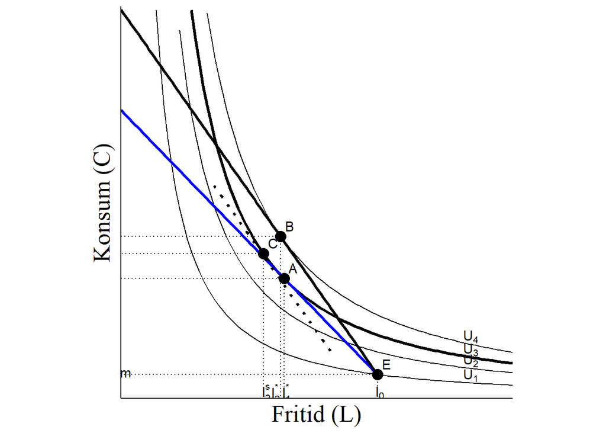

```r
# Clear the workspace
rm(list = ls())
library(extrafont)

suppressPackageStartupMessages(library(tidyverse))

    # Opprette en sekvens og lagre den i l_1
    l_1 <- seq(0, 168)  # l_1 representerer fritid, går fra 70 til 200

    # Konverterer sekvensen til en data.frame
    df <- data.frame(l_1)  # Dette gjør det enklere å håndtere i ggplot

    # Forbereder en ggplot-graf med definerte estetiske verdier og navn på aksene
    # Definer plottet med akser
    axes_1 <- ggplot(df, aes(l_1)) +
      labs(
        x = "Fritid (L)",
        y = "Konsum (C)") +
      coord_fixed(ratio = 168/16300) +  # sørg for at skalaen for x og y er den samme
      theme(axis.title = element_text(size = 20),
            panel.background = element_blank(),  # hvit bakgrunn
            axis.line = element_line(colour = "black"),  # tegn akselinjer
           # axis.ticks = element_line(),  # vis tick marks
           axis.ticks = element_blank(),  # ta bort tick marks
           axis.text.x = element_blank(),  # vis x-akseetiketter
            axis.text.y = element_blank(),  # vis y-akseetiketter
            text = element_text(family = "Times New Roman")) +  # Sett standard font til Times New Roman
      scale_x_continuous(limits = c(0, 168), expand = c(0, 0)) +  # begrens akser og sett tick marks
      scale_y_continuous(limits = c(0, 16300), expand = c(0, 0))  # begrens akser og sett tick marks

      # Definer Cobb-Douglas nyttefunksjoner
      alpha <- 0.58333333333
      U_1 <- 276.35
      U_2 <- 364
      U_3 <- 414.01  # Justerer nyttenivåer slik at de passer inn i figuren
      U_4 <- 464


      # Funksjoner for indifferenskurver
      C_1 <- function(l_1) (U_1 / (l_1^alpha))^(1 / (1 - alpha))
      C_2 <- function(l_1) (U_2 / (l_1^alpha))^(1 / (1 - alpha))
      C_3 <- function(l_1) (U_3 / (l_1^alpha))^(1 / (1 - alpha))
      C_4 <- function(l_1) (U_4 / (l_1^alpha))^(1 / (1 - alpha))

    # Definer budsjetbetingelsen
    budget_constraint <- function(l_1) {
      12000 - 100 * l_1
    }

    # Definer ligningen for reservasjonslønna

    #reservation_wage <- function(l_1) {
   #   c=2400.3 −12.73*l_1
  #  }

   # Definer budsjetbetingelsen den nye budsjettbetingelsen
    budget_constraint_2 <- function(l_1) {
      16180 - 138 * l_1
    }

    # Definer tangent til U_# med nye lønna
    tangent    <- function(l_1) {
      14378.354 - 138 * l_1
    }
    # Legg til inndifferenskurvene i figuren
    figure_3 <- axes_1 +
      stat_function(fun = C_1, aes(colour = NULL), colour = "black") +
      stat_function(fun = C_2, aes(colour = NULL), colour = "black") +
      stat_function(fun = C_3, aes(colour = NULL), colour = "black", size = 1.2) +  # Tykkere linje for U_3
      stat_function(fun = C_4, aes(colour = NULL), colour = "black") +
      annotate("text", x = 150, y = C_1(150), label = "U[1]",size = 4, parse = TRUE, vjust = -0.1) +
      annotate("text", x = 150, y = C_2(150), label = "U[2]",size = 4, parse = TRUE, vjust = -0.1) +
      annotate("text", x = 150, y = C_3(150), label = "U[3]",size = 4, parse = TRUE, vjust = -0.1) +
      annotate("text", x = 150, y = C_4(150), label = "U[4]",size = 4, parse = TRUE, vjust = -0.1) +
      stat_function(fun = budget_constraint, aes(colour = NULL), colour = "blue", xlim = c(0, 110), size = 1.2) +  # Tykkere linje for budsjett
      stat_function(fun = budget_constraint_2, aes(colour = NULL), colour = "black", xlim = c(0, 110), size = 1.2) +  # Tykkere linje for budsjett
      stat_function(fun = tangent, aes(colour = NULL), colour = "black", xlim = c(40, 90),linetype = "dotted", size = 1.2) +  # Tykkere linje for budsjett
      geom_segment(aes(x = 70, y = 5000, xend = 70, yend = 0), linetype = "dotted") +
      geom_segment(aes(x = 70, y = 5000, xend = 0, yend = 5000), linetype = "dotted") +
      geom_segment(aes(x = 110, y = 1000, xend = 0, yend = 1000), linetype = "dotted") + # horisontal linje fra (70, 5000) til (70, 0)
      geom_point(aes(x = 70, y = 5000), colour = "black", size = 4) +  # Svart prikk på (70, 5000)
      annotate("text", x = 72, y = 5000, label = "A", hjust = 0, size = 4, vjust = -0.5) +  # Merk prikk "P"
      geom_segment(aes(x = 110, y = 1000, xend = 110, yend = 0), linetype = "dotted") +  #Vertikal linje fra (70, 5000) til (70, 11000)
      geom_point(aes(x = 110, y = 1000), colour = "black", size = 4) +  # Svart prikk på (110, 1000)+
      annotate("text", x = 112, y = 1000, label = "E", hjust = 0, size = 4, vjust = -0.5)+ # Merk prikk "E"
      annotate("text", x = 113, y = 250, label = "l[0]", hjust = 1, size = 4, parse = TRUE) +
      annotate("text", x = 73, y = 250, label = expression(l[1]^"*"), hjust = 1, size = 4, parse = TRUE) +
      annotate("text", x = 64.133, y = 250, label = expression(l[2]^"s"), hjust = 1, size = 4, parse = TRUE) +
      annotate("text", x = 68.21, y = 250, label = expression(l[2]^"*"), hjust = 1, size = 4, parse = TRUE) +
      annotate("text", x = 2, y = 1200, label = "m", vjust = 1, size = 4, parse = TRUE)+
      geom_segment(aes(x = 68.41, y = 6745.97, xend = 68.41, yend = 0), linetype = "dotted") +
      geom_segment(aes(x = 68.41, y = 6745.97, xend = 0, yend = 6745.97), linetype = "dotted")+
     geom_point(aes(x = 68.41, y = 6745.97), colour = "black", size = 4) +  # Svart prikk
      annotate("text", x = 70.41, y = 6745.97, label = "B", hjust = 0, size = 4, vjust = -0.5)+  # Merk prikk "B"
      geom_point(aes(x = 61.133, y = 6026), colour = "black", size = 4) +  # Svart prikk
      annotate("text", x = 63.133, y = 6026, label = "C", hjust = 0, size = 4, vjust = -0.5)+  # Merk prikk "C"
      geom_segment(aes(x = 61.133, y = 6026, xend = 61.133, yend = 0), linetype = "dotted") +
      geom_segment(aes(x = 61.133, y = 6026, xend = 0, yend = 6026), linetype = "dotted")


    # Skriv ut figuren
    print(figure_3)
```

Nytt optimalt valg: B $(c_2^*, l_2^*)$

Substitusjonseffekt: A ==> C: $l_1^* \rightarrow l_2^s$

Inntektseffekt: C ==> B: $l_2^s \rightarrow l_2^*$

## Intuisjon

Intuisjon: En høyere lønn fører til at alternativkostnaden for å ha fri øker. Dersom Helle tar fri én time går hun glipp av mer konsum enn tidligere. Dette gir henne insentiver til å jobbe flere timer. Dette gir intuisjon til substitusjonseffekten. Den fører alltid til flere arbeidstimer (mindre fritid).

En høyere lønn fører til at Helle kan konsumere mer ved et gitt antall arbeidstimer. Hun kan også beholde samme nivå av konsum, selv om hun reduserer mengden arbeidstimer. Helle har med andre ord råd å ha mer fri. Dersom fritid er et normalt gode vil dette gi henne insentiver til å minke arbeidstilbudet. Dette gir intuisjon til inntektseffekten.

## f) Utled Helle sitt arbeidstilbud ($h^{*}(w,m,\ \alpha,\beta$) matematisk. Tegne opp arbeidstilbudet i en graf der du har timelønna på y-aksen og optimal mengde arbeidstimer på x-aksen (trenger ikke å være eksakt).

## Matematisk analyse

$$\max_{c,l,\lambda}{\mathcal{L =}c^{\alpha} \cdot l^{\beta} + \lambda \cdot \left( m + w \cdot (T - l) - c \right)}$$

Førsteordensbetingelser:

1. **Med hensyn på** $c$:
   $$\frac{\partial \mathcal{L}}{\partial c} = 0 \implies \alpha \cdot c^{\alpha - 1} \cdot l^{\beta} - \lambda = 0$$
2. **Med hensyn på** $l$:

$$\frac{\partial \mathcal{L}}{\partial l} = 0 \implies \beta \cdot c^{\alpha} \cdot l^{\beta - 1} - \lambda \cdot w = 0$$

3. **Med hensyn på** $\lambda$:

   $$\frac{\partial \mathcal{L}}{\partial \lambda} = 0 \implies m + w \cdot (T - l) - c = 0$$

Vi kan skrive om ligning (1) og ligning (2) slik at begge er lik $\lambda$, og bruke dette for å sette de to ligningene lik hverandre. Vi kan deretter skrive det optimale nivået på konsum som en funksjon av fritid, arbeidsfri inntekt, og lønn.

$$\alpha \cdot c^{\alpha - 1} \cdot l^{\beta} = \lambda$$

$$\beta \cdot c^{\alpha} \cdot l^{\beta - 1} \cdot \frac{1}{w} = \lambda$$

$$\alpha \cdot c^{\alpha - 1} \cdot l^{\beta} = \beta \cdot c^{\alpha} \cdot l^{\beta - 1} \cdot \frac{1}{w}$$

$$\frac{\alpha \cdot c^{\alpha - 1} \cdot l^{\beta}}{\beta \cdot c^{\alpha} \cdot l^{\beta - 1}} = \frac{1}{w}$$

$$\frac{\alpha \cdot l}{\beta \cdot c} = \frac{1}{w}$$

$$\frac{\alpha}{\beta} \cdot l = \frac{1}{w} \cdot c$$

$$\frac{\alpha}{\beta} \cdot l^{*}\ \cdot w = c^{*}$$

Vi kan nå substituere vår løsning inn i ligning (3) for å så løse for det optimale nivået på fritid (og konsum).

$$m + w \cdot \left( T - l^{*} \right) - c^{*} = 0$$

$$m + w \cdot \left( T - l^{*} \right) - \frac{\alpha}{\beta} \cdot l^{*}\ \cdot w = 0$$

$$m + w \cdot T - w \cdot \left( l^{*} + \frac{\alpha}{\beta} \cdot l^{*} \right) = 0$$

$$m + w \cdot T - w \cdot l^{*} \cdot \left( 1 + \frac{\alpha}{\beta} \right) = 0$$

$$m + w \cdot T - w \cdot l^{*} \cdot \left( \frac{\beta + \alpha}{\beta} \right) = 0$$

$$m + w \cdot T = w \cdot l^{*} \cdot \left( \frac{\alpha + \beta}{\beta} \right)$$

$$(m + w \cdot T) \cdot \frac{1}{w} \cdot \left( \frac{\beta}{\alpha + \beta} \right) = l^{*}$$

$$l^{*} = \left( \frac{\beta}{\alpha + \beta} \right) \cdot \left( \frac{m}{w} + T \right)$$

For å få fram Helle sitt arbeidstilbud, må vi ta fram et uttrykk for $h^{*}(m,w,T,\ \alpha,\beta\ )$. Vi bruker at $h^{*} = T - l^{*}$, og substituerer inn for $l^{*}.$

$$h^{*} = T - \left( \frac{\beta}{\alpha + \beta} \right) \cdot \left( \frac{m}{w} + T \right)$$

$$h^{*} = T - \left( \frac{\beta}{\alpha + \beta} \right) \bullet \frac{m}{w} - \left( \frac{\beta}{\alpha + \beta} \right) \bullet T$$

Vi kan forenkle dette uttrykket, slik at det gir bedre intuisjon.

$$h^{*} = T \cdot \left( 1 - \frac{\beta}{\alpha + \beta} \right) - \left( \frac{\beta}{\alpha + \beta} \right) \cdot \frac{m}{w}$$

$$h^{*} = T \cdot \left( \frac{\alpha + \beta}{\alpha + \beta} - \frac{\beta}{\alpha + \beta} \right) - \left( \frac{\beta}{\alpha + \beta} \right) \cdot \frac{m}{w}$$

$$h^{*} = T \cdot \left( \frac{\alpha}{\alpha + \beta} \right) - \left( \frac{\beta}{\alpha + \beta} \right) \cdot \frac{m}{w}$$

**Intuisjonssjekk: 1)** teste hva som skjer med arbeidstilbudet dersom lønna øker. Vi forventer oss enten en positiv effekt, eller at vi ser en positiv effekt (substitusjonseffekt) og en negativ effekt (inntektseffekt). **2)** teste hva som skjer dersom arbeidsfri inntekt øker. Vi forventer oss at arbeidstilbudet vil være mindre, jo høyere $m$ er.

For å tegne inn dette i en graf må først se hvilken lønn som gir $h^{*} = 0$. Dette er Helle sin reservasjonslønn.

$$0 = T \cdot \left( \frac{\alpha}{\alpha + \beta} \right) - \left( \frac{\beta}{\alpha + \beta} \right) \cdot \frac{m}{w^{r}}$$

$$T \cdot \left( \frac{\alpha}{\alpha + \beta} \right) = \left( \frac{\beta}{\alpha + \beta} \right) \cdot \frac{m}{w^{r}}$$

$$\frac{T}{m} \cdot \left( \frac{\alpha}{\alpha + \beta} \right) \cdot \left( \frac{\alpha + \beta}{\beta} \right) = \frac{1}{w^{r}}$$

$$\frac{T}{m} \cdot \frac{\alpha}{\beta} = \frac{1}{w^{r}}$$

$$w^{r} = \frac{m}{T} \cdot \frac{\beta}{\alpha}$$

Vi ser at jo høyere arbeidsfri inntekt Helle har, desto høyere må timelønna være for at hun skal være villig å jobbe i det hele tatt. Vi ser også at, jo mer Helle vurderer fritid ($\beta$), desto høyere vil reservasjonslønna være.

## Grafisk analyse

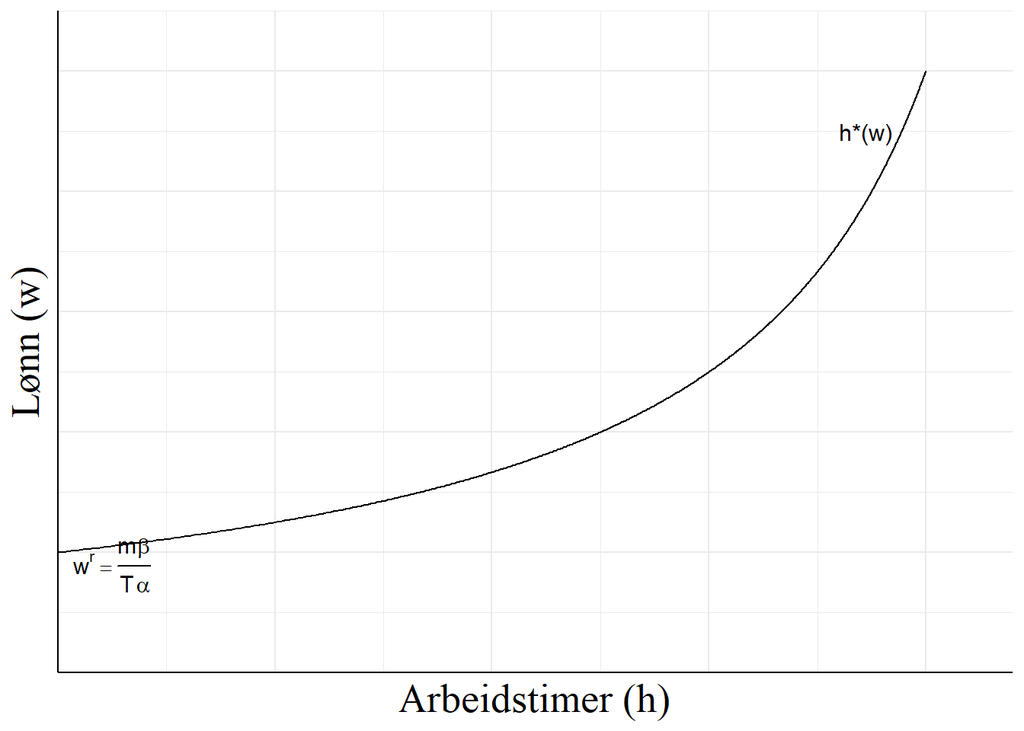

```r
# Clear the workspace
rm(list = ls())
library(extrafont)

suppressPackageStartupMessages(library(tidyverse))
    # Load necessary libraries
library(ggplot2)
library(scales)

# Define parameters
m <- 1
T <- 1
beta <- 1
alpha <- 1
w_r <- (m / T) * (beta / alpha)

# Define the h*(w) function
h_star <- function(w) {
  return(T * (1 - (w_r / w)^alpha))
}

# Create data frame
w_values <- seq(w_r, w_r * 5, length.out = 1000)
df <- data.frame(
  h = h_star(w_values),
  w = w_values
)

# Create the plot
ggplot(df, aes(x = h, y = w)) +
      labs(
        x = "Arbeidstimer (h)",
        y = "Lønn (w)") +
  geom_line() +
  scale_y_continuous(
    expand = c(0, 0),
    limits = c(0, max(df$w) * 1.1),
    labels = scales::label_number(accuracy = 0.01)
  ) +
  scale_x_continuous(
    expand = c(0, 0),
    limits = c(0, max(df$h) * 1.1)
  ) +
  annotate("text", x = max(df$h) * 0.9, y = max(df$w) * 0.9,
           label = "h*(w)", hjust = 0, size = 4) +
    # Add the equation annotation within the plot area
  annotate("text", x = 0.05, y = 0.9,
           label = "w^r == frac(m, T) * frac(beta, alpha)",
           parse = TRUE, size = 4) +
  theme_minimal() +
  theme(axis.title = element_text(size = 20),
            panel.background = element_blank(),  # hvit bakgrunn
            axis.line = element_line(colour = "black"),  # tegn akselinjer
           # axis.ticks = element_line(),  # vis tick marks
           axis.ticks = element_blank(),  # ta bort tick marks
           axis.text.x = element_blank(),  # vis x-akseetiketter
            axis.text.y = element_blank(),  # vis y-akseetiketter
            text = element_text(family = "Times New Roman"))   # Sett standard font til Times New Roman
```